# Introduction to Logistic Regression

Lecture 2A

PUBHBIO 6250

## Example Data Set: WCGS

Western Collaborative Group Study (WCGS):

- Epidemiologic study of risk factors for coronary heart disease (CHD)
- $n$ = 3,152 men
- Dropped 12 men missing cholesterol, leaving $n$ = 3,140 men for analysis
- Age range 39 - 59 years
- Employed in one of 10 companies in CA
- Baseline examination in 1960
- Followed until 1969, when 255 of the men had a diagnosis of heart disease

We will use these data for illustration of logistic regression in this course.

## CHD Risk

- Let CHD$_i = 1$ if subject has CHD, and $0$ otherwise.
- **Research Question:** What is the relationship between age (predictor) and presence of CHD (response)?
- Linear regression is **NOT** appropriate for this response/outcome variable.
  - **Problem 1:** linear regression assumes distribution of $CHD|Age$ is normal $\longrightarrow$ **definitely not true!**
  - **Problem 2:** predicted CHD values might be $<0$ or $>1$ $\longrightarrow$ **no constraint on $\hat{Y}$**.

## Why shouldn’t we do a t-test?

- Want to **predict CHD** occurrence using age (at study entry)
- **CHD is the outcome**
  - Temporally, CHD comes after age at entry
  - Doesn’t make sense to use CHD to predict age at entry!
- $Y=CHD$ (binary)
- $X=age$ (continuous/discrete)
- Want to model for $E(Y|X)=E(CHD|Age)$

## Solution: Logistic Model

- We are modeling: $E(CHD|Age)=P(CHD=1|Age)$
  - Mean (expected value) of a binary $0/1$ variable is the probability of a $1$.
- Instead of assuming a **linear relationship** between age and $P(CHD=1)$, we assume a **logistic relationship**

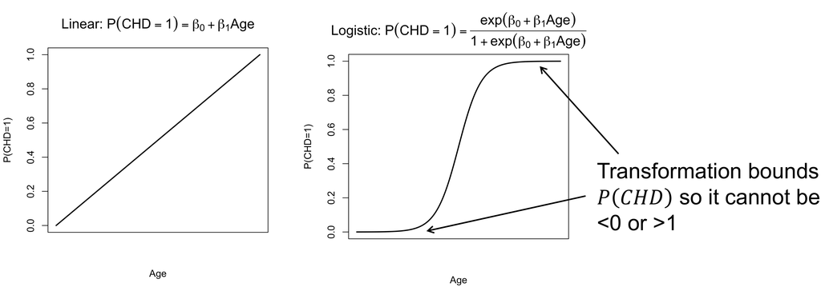

## Logistic Regression

- For dichotomous outcome $Y$ and predictor $X$:

$$E(Y|X) = P(Y=1|X)= \frac{\exp\{\beta_0+\beta_1X\}}{1+\exp\{\beta_0+\beta_1X\}}$$

- This is the **logistic function**.
- $-\infty<\beta_0<\infty$, $-\infty<\beta_1<\infty$
- $0\leq P(X) \leq 1$
- Note that:

$$P(Y=0|X) = 1-P(Y=1|X)=\frac{1}{1+\exp\{\beta_0+\beta_1X\}}$$

## Logit Function

- Logit function

$$\begin{aligned}
g(x) &= \textcolor{#0000FF}{\boldsymbol{\log}} \left( \frac{P(Y=1|x)}{1 - P(Y=1|x)}\right) \\
&= \log \left( \frac{\exp(\beta_0 + \beta_1 x)/(1 + \exp(\beta_0 + \beta_1 x))}{1/(1 + \exp(\beta_0 + \beta_1 x))}\right) \\
&= \log \left( \exp(\beta_0 + \beta_1 x) \right) \\
&= \beta_0 + \beta_1 x
\end{aligned}$$

- $P(Y=0|x) = 1 - P(Y=1|x)$
- $\log$ is the natural log, with base $e$. ($e$ is approximately 2.71828)
- $-\infty < g(x) < \infty$

## Assumptions of Logistic Regression Model

**Population model:** $\quad \text{logit} \left(E(Y|X)\right)=\text{logit} \left(P(Y=1|X) \right)=\beta_0 +\beta_1 X$

**Assumptions**

1. *Distribution*: $Y$ follows a **Binomial** distribution
2. *Linearity*: The mean, $E(Y|X)$, is given by the **logistic function**
   - Implies that $\text{logit}(E(Y|X))$ is a linear function of $X$
3. *Independence*: Values of $Y$ are **independent**

**NOTE**: no error terms!

## Review: Binomial Distribution

- Let $Y=\#$ successes out of $n$ trials.
  - e.g., number of heads in 10 flips of coin
- $Y$ has **probability mass function:**

$$\text{Pr}(Y=k)=\frac{n!}{k!(n-k)!}p^k(1-p)^{n-k}$$

- $k=0,1,\ldots,n$
- $p$ = success probability
- **Mean:** $E(Y)=np$
- **Variance:** $Var(Y)=np(1-p)$

## Distribution of CHD$_i$

- Let person $i$ have $n=1$ trial.
  - CHD = success, no CHD = failure
- CHD$_i$ is a binomial random variable:

$$\begin{aligned}
Pr(\text{CHD}_i=k) &= \frac{n!}{k!(n-k)!} \times p_i^k(1-p_i)^{n-k} \\
&= \textcolor{#0000FF}{\boldsymbol{\frac{1!}{k!(1-k)!}}} \times p_i^k(1-p_i)^{1-k} \\
&= \textcolor{#0000FF}{\boldsymbol{1}} \times p_i^k(1-p_i)^{1-k}
\end{aligned}$$

- $k= 0$ $\rightarrow$ $Pr(\text{CHD}_i = 0) = p_i^0 (1 - p_i)^{(1-0)} = 1 - p_i$
- $k= 1$ $\rightarrow$ $Pr(\text{CHD}_i = 1) = p_i^{1} (1 - p_i)^{(1-1)} = p_i$

## Estimation Method

- In linear regression, $E(Y|x)=\beta_0+\beta_1 x$ and we found $\hat{\beta}_0$ and $\hat{\beta}_1$ which minimize:

$$SSE=\sum_{i=1}^n(y_i-(\beta_0+\beta_1x_i))^2$$

- In logistic regression we use **maximum likelihood estimation**.
  - $\hat{\beta}_0$ and $\hat{\beta}_1$ maximize the probability of obtaining the observed data.
  - Maximum likelihood and least squares estimation yield the same results for $\hat{\beta}_0$ and $\hat{\beta}_1$ in linear regression.

## Likelihood Function

- Gives probability of observed data given $\beta_0$ and $\beta_1$.
- The probability of observing $y_i$ for subject $i$ with the predictor $x_i$ is:

$$Pr (Y_i=y_i|x_i) = \textcolor{#BB0000}{\boldsymbol{p(x_i)^{y_i}}}\textcolor{#0000FF}{\boldsymbol{(1-p(x_i))^{1-y_i}}}$$

- $y_i=0,1$
- Likelihood function is the **joint probability** of observing the data of all $n$ subjects:

$$L(\beta) = \prod_{i=1}^n Pr (Y_i=y_i|x_i)= \prod_{i=1}^{n} p(x_i)^{y_i} \left(1 - p(x_i)\right)^{1-y_i}, \text{ where } p_i = \frac{\exp(\beta_0 + \beta_1 x_i)}{1 + \exp(\beta_0 + \beta_1 x_i)}$$

## Maximizing the Log Likelihood

- Easier mathematically to maximize the log likelihood:

$$\begin{aligned}
\ell(\beta_0, \beta_1) &= \log\{L(\beta_0, \beta_1)\} = \sum_{i=1}^n\log\{Pr(Y_i=y_i|x_i)\} \\
&= \sum_{i=1}^{n} \log \left\{ p(x_i)^{y_i} \left(1 - p(x_i)\right)^{1-y_i} \right\}, \text{ where } p_i = \frac{\exp(\beta_0 + \beta_1 x_i)}{1 + \exp(\beta_0 + \beta_1 x_i)}
\end{aligned}$$

- Differentiate $\ell(\beta_0, \beta_1)$ with respect to $\beta_0$ and $\beta_1$ and set both equations to 0:

$$\begin{aligned}
\frac{\partial \ell(\beta_0, \beta_1)}{ \partial \beta_0} &= \sum_{i=1}^n(y_i-p(x_i))=0
\qquad
\frac{\partial \ell(\beta_0, \beta_1)}{ \partial \beta_1} &=\sum_{i=1}^n x_i(y_i-p(x_i))=0
\end{aligned}$$

- Solving for $\hat{\beta}_0$ and $\hat{\beta}_1$ requires an iterative procedure (**understanding this procedure is not required for this class**).